# Bellabeat Case study

## Introduction

In this case study, I will be analyzing fitness tracker data for Bellabeat, a high-tech manufacturer of health-focused products for women.The goal is to gain insights into consumer usage of these products, which will inform Bellabeat’s future marketing strategies.

To address the key business questions, I will follow the steps of the data analysis process: asking questions, preparing data, processing data, analyzing data, sharing findings, and taking action.

## Business Task

Urška Sršen , cofounder and Chief Creative Officer of Bellabeat, has requested an analysis of smart device usage data to gain insights into how consumers use non-Bellabeat smart devices. The goal is to apply these insights to a specific Bellabeat product and provide recommendations to influence Bellabeat’s marketing strategy.I’ve chosen to focus my analysis on Leaf, Bellabeat’s classic wellness tracker. This versatile device can be worn as a bracelet, necklace, or clip. The Leaf tracker connects to the Bellabeat app, where it monitors and tracks activity, sleep, and stress levels.

## Data Sources Used

https://www.kaggle.com/datasets/arashnic/fitbit

## Data Cleaning and Manipulation

- Conversion of Columns: Dates were converted to Date format and times to POSIXct.
- Removal of Duplicates: Ensured unique entries by id and ActivityHour.
- Handling Outliers: Outliers were removed from the dataset to ensure data accuracy.
- Merging Datasets: Data from various sources was merged for comprehensive analysis.

```r
# Install packages
if(!require(tidyverse)) {
  install.packages("tidyverse");
  require(tidyverse)}
```

```r
if(!require(dplyr)) {
  install.packages("dplyr");
  require(dplyr)}

if(!require(lubridate)) {
  install.packages("lubridate");
  require(lubridate)}

if(!require(ggplot2)) {
  install.packages("ggplot2");
  require(ggplot2)}

if(!require(ggcorrplot)) {
  install.packages("ggcorrplot");
  require(ggcorrplot)}
if(!require(readr)) {
  install.packages("readr");
  require(readr)}
```

```r
#loading important packages
library(lubridate)
library(ggplot2)
library(ggcorrplot)
library(dplyr)
library(magrittr)
library(readr)
library(cluster)
library(gridExtra)
#importing datasets
 dailyActivity <- read_csv("Fitabase Data 4.12.16-5.12.16/dailyActivity_merged.csv")
 hourlyCalories <- read_csv("Fitabase Data 4.12.16-5.12.16/hourlyCalories_merged.csv")
 hourlyIntensities <- read_csv("Fitabase Data 4.12.16-5.12.16/hourlyIntensities_merged.csv")
 hourlySteps <- read_csv("Fitabase Data 4.12.16-5.12.16/hourlySteps_merged.csv")
 weightLog <- read_csv("Fitabase Data 4.12.16-5.12.16/weightLogInfo_merged.csv")
 sleepDay <- read_csv("Fitabase Data 4.12.16-5.12.16/sleepDay_merged.csv")
 heartrate <- read_csv("Fitabase Data 4.12.16-5.12.16/heartrate_seconds_merged.csv")
 minuteCalories <- read_csv("~/Fitabase Data 4.12.16-5.12.16/minuteCaloriesNarrow_merged.csv")
 minuteIntensities <- read_csv("~/Fitabase Data 4.12.16-5.12.16/minuteCaloriesNarrow_merged.csv")
 minuteSteps <- read_csv("~/Fitabase Data 4.12.16-5.12.16/minuteCaloriesNarrow_merged.csv")
 minuteMETs <- read_csv("~/Fitabase Data 4.12.16-5.12.16/minuteCaloriesNarrow_merged.csv")
#Perform the joins
# Convert ActivityHour to POSIXct (date-time) format using lubridate
hourlySteps$ActivityHour <- mdy_hms(hourlySteps$ActivityHour)
hourlyCalories$ActivityHour <- mdy_hms(hourlyCalories$ActivityHour)
hourlyIntensities$ActivityHour <- mdy_hms(hourlyIntensities$ActivityHour)
minuteIntensities$ActivityMinute <- mdy_hms(minuteIntensities$ActivityMinute)
minuteCalories$ActivityMinute <- mdy_hms(minuteCalories$ActivityMinute)
minuteMETs$ActivityMinute <- mdy_hms(minuteMETs$ActivityMinute)
minuteSteps$ActivityMinute <- mdy_hms(minuteSteps$ActivityMinute)


# verify to ensure the column is POSIXct
str(hourlySteps$ActivityHour)
```

```
##  POSIXct[1:22099], format: "2016-04-12 00:00:00" "2016-04-12 01:00:00" "2016-04-12 02:00:00" ...
```

```r
# Check for NAs
sum(is.na(hourlySteps$ActivityHour))
```

```
## [1] 0
```

```r
sum(is.na(hourlyCalories$ActivityHour))
```

```
## [1] 0
```

```r
sum(is.na(hourlyIntensities$ActivityHour))
```

```
## [1] 0
```

```r
sum(is.na(minuteIntensities$ActivityMinute))
```

```
## [1] 0
```

```r
sum(is.na(minuteCalories$ActivityMinute))
```

```
## [1] 0
```

```r
sum(is.na(minuteSteps$ActivityMinute))
```

```
## [1] 0
```

```r
sum(is.na(minuteMETs$ActivityMinute))
```

```
## [1] 0
```

```r
# Perform the joins
joined_data <- hourlySteps %>%
  inner_join(hourlyCalories, by = c("Id", "ActivityHour")) %>%
  inner_join(hourlyIntensities, by = c("Id", "ActivityHour"))

joined_minute_data <- minuteSteps %>%
  inner_join(minuteCalories, by = c("Id", "ActivityMinute")) %>%
  inner_join(minuteIntensities, by = c("Id", "ActivityMinute"))%>%
inner_join(minuteMETs, by = c("Id", "ActivityMinute"))
```

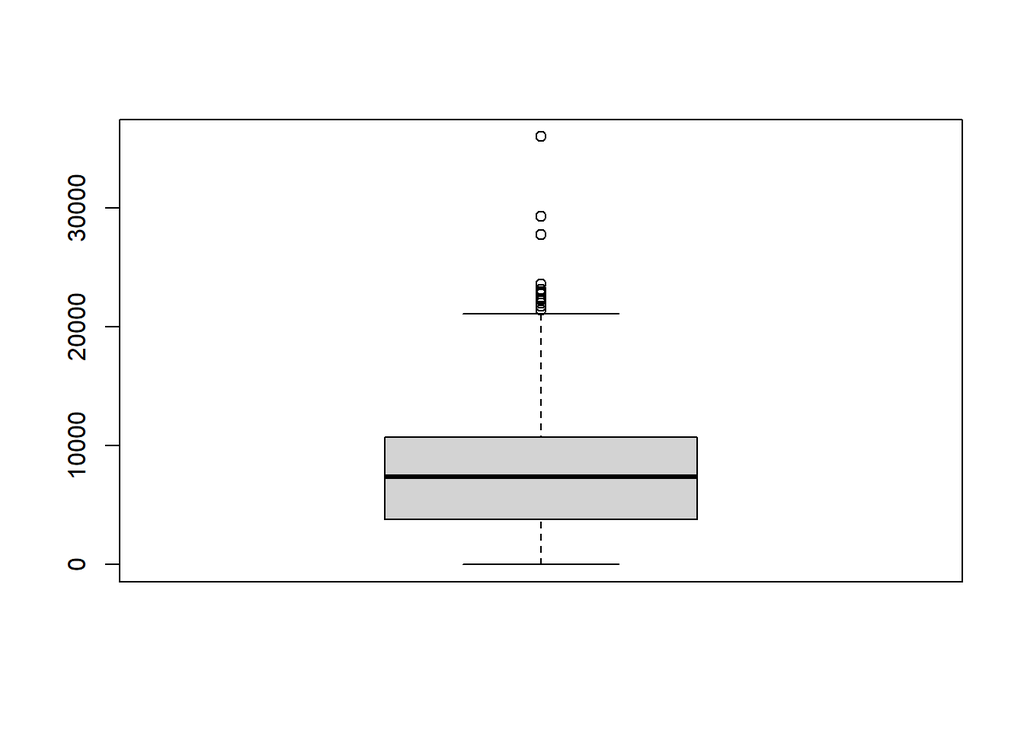

```r
#Analyzing the daily activity dataset to see what days customers tend to be more active
#remove duplicates using dplyr
  dailyActivity <- dailyActivity %>% distinct()

# check for outliers using summary statistics
  boxplot(dailyActivity$TotalSteps)
```

### **How does user’s activity vary throughout the week?**

```r
#Remove outliers first and create a new column called Dayofweek and summarize totalsteps by dayofweek to identify on which days people are more active
dim(dailyActivity)
```

```
## [1] 940  15
```

```r
 quartiles <- quantile(dailyActivity$TotalSteps, probs=c(.25, .75), na.rm = FALSE)
IQR <- IQR(dailyActivity$TotalSteps)
  Lower <- quartiles[1] - 1.5*IQR
  Upper <- quartiles[2] + 1.5*IQR
  Data_No_Outlier <- subset(dailyActivity, dailyActivity$TotalSteps > Lower & dailyActivity$TotalSteps < Upper)
dim(Data_No_Outlier)
```

```
## [1] 928  15
```

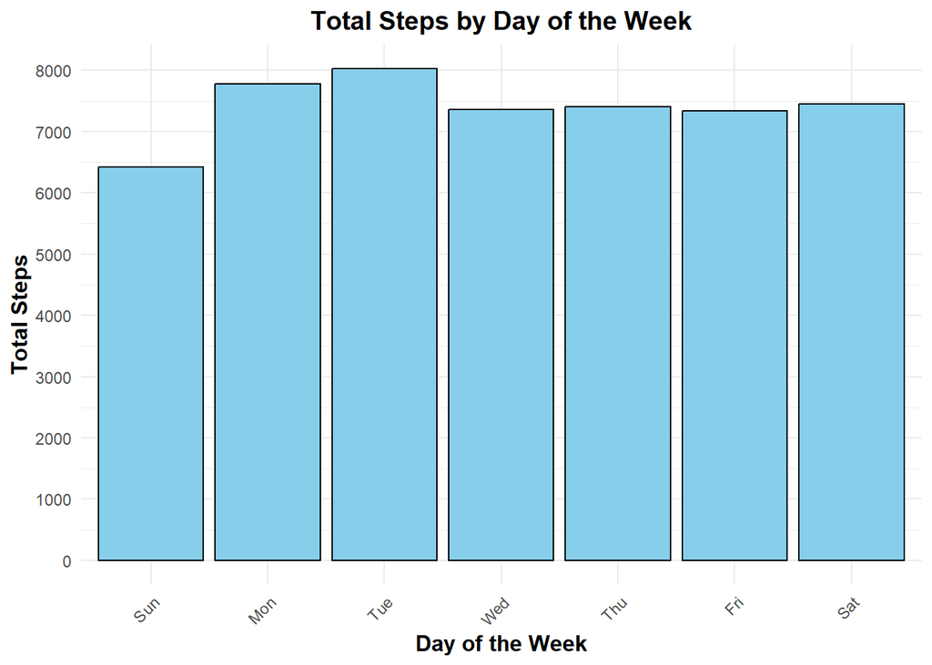

```r
Data_No_Outlier$ActivityDate <- mdy(Data_No_Outlier$ActivityDate)
 dailyActivityUpdated <- Data_No_Outlier %>%
 mutate(DayOfWeek = wday(Data_No_Outlier$ActivityDate, label = TRUE))
 ActivityByDay <- dailyActivityUpdated %>%
    group_by(DayOfWeek) %>%
summarize(TotalSteps = mean(TotalSteps))

# Create the plot
ggplot(ActivityByDay, aes(x=DayOfWeek, y=TotalSteps)) +
  geom_bar(stat="identity", fill="skyblue", color="black") +
  labs(title="Total Steps by Day of the Week", x="Day of the Week", y="Total Steps") +
  scale_y_continuous(breaks = seq(0, max(ActivityByDay$TotalSteps), by = 1000)) +
  theme_minimal() +
  theme(
    axis.text.x = element_text(angle=45, hjust=1),  # Rotate x-axis labels
    plot.title = element_text(hjust=0.5, size=14, face="bold"),  # Center title
    axis.title = element_text(size=12, face="bold")  # Bold axis titles
  )
```

-As we can see on the data there’s some variation of activity level throughout the week and Bellabeat can make informed decisions based on the findings like.

-Bellabeat should consider Introducing midweek challenges or rewards to encourage higher engagement on days with minimal activity.

-Schedule marketing campaigns and promotions to align with the higher activity levels on Mondays and Tuesdays.

### **How many unique users recorded their daily activity data?**

```r
unique_daily_users <- n_distinct(dailyActivity$Id)
print(paste("Unique daily users:", unique_daily_users))
```

```
## [1] "Unique daily users: 33"
```

```r
unique_hourly_users <- n_distinct(joined_data$Id)
print(paste("Unique hourly users:", unique_hourly_users))
```

```
## [1] "Unique hourly users: 33"
```

```r
unique_minute_users <- n_distinct(joined_minute_data$Id)
print(paste("Unique minute users:", unique_minute_users))
```

```
## [1] "Unique minute users: 33"
```

```r
unique_sleep_day <- n_distinct(sleepDay$Id)
print(paste("Unique sleep day:", unique_sleep_day))
```

```
## [1] "Unique sleep day: 24"
```

```r
unique_weightLog <- n_distinct(weightLog$Id)
print(paste("Unique weight log:", unique_daily_users))
```

```
## [1] "Unique weight log: 33"
```

```r
unique_heartrate <- n_distinct(heartrate$Id)
print(paste("Unique heartrate:", unique_heartrate))
```

```
## [1] "Unique heartrate: 14"
```

```r
# Create a data frame to store the unique user counts
unique_users_df <- data.frame(
  ActivityType = c("Daily", "Hourly", "Minute-by-Minute", "Sleep", "Weight", "Heart Rate"),
  UniqueUsers = c(unique_daily_users, unique_hourly_users, unique_minute_users, unique_sleep_day, unique_weightLog, unique_heartrate)
)

# Print the data frame to check the values
print(unique_users_df)
```

```
##       ActivityType UniqueUsers
## 1            Daily          33
## 2           Hourly          33
## 3 Minute-by-Minute          33
## 4            Sleep          24
## 5           Weight           8
## 6       Heart Rate          14
```

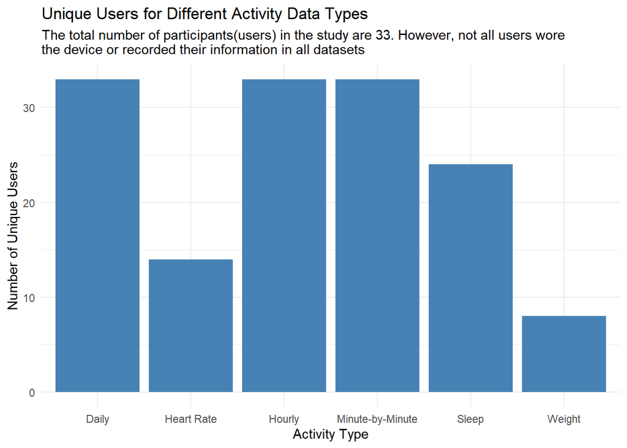

```r
# Plot the unique user counts using ggplot2
ggplot(unique_users_df, aes(x = ActivityType, y = UniqueUsers)) +
  geom_bar(stat = "identity", fill = "steelblue") +
  labs(title = "Unique Users for Different Activity Data Types",
       subtitle="The total number of participants(users) in the study are 33. However, not all users wore
the device or recorded their information in all datasets ",
       x = "Activity Type",
       y = "Number of Unique Users") +
  theme_minimal()
```

The number of unique users recording weight data (8) and heart rate data (14) is lower compared to other metrics. To address this, Bellabeat could gather feedback from users to understand the barriers to recording weight and heart rate data. By addressing these barriers, Bellabeat can improve overall data collection. Additionally, I recommend increasing engagement with weight and heart rate tracking through promotions, incentives, and educational content. Offering personalized tips and reminders within the app, as well as integrating social sharing features, can also motivate users to consistently track their health metrics.

### **Are there any trends indicating a drop in device usage over time?**

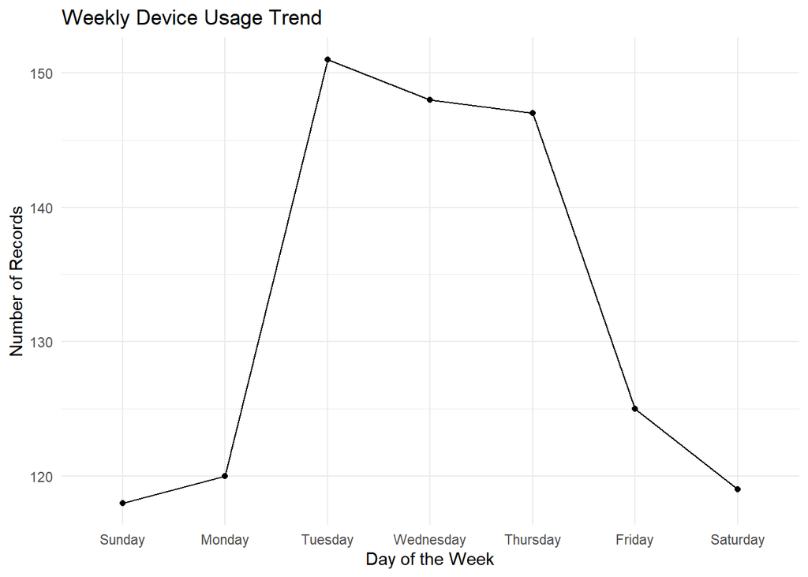

```r
# Extract the day of the week from the ActivityDate
dailyActivityUpdated <- dailyActivityUpdated %>%
  mutate(DayOfWeek = wday(ActivityDate, label = TRUE, abbr = FALSE))

# Summarize the number of records for each day of the week
weekly_usage <- dailyActivityUpdated %>%
  group_by(DayOfWeek) %>%
  summarise(records = n())

# Plot the trend
ggplot(weekly_usage, aes(x = DayOfWeek, y = records)) +
  geom_line(group = 1) + # Specify group = 1 for a single line
  geom_point() + # Add points to the line for better visualization
  labs(title = "Weekly Device Usage Trend", x = "Day of the Week", y = "Number of Records") +
  theme_minimal()
```

The weekly device usage trend show significant variation throughout the week, The peak in usage from Tuesday to Thursday might correspond with users’ typical weekly activities, such as work-related activities, fitness routines, or other scheduled events.

Bellabeat should gather feedback from users to understand their routines and reasons for this usage pattern, which can provide actionable insights for improving engagement strategies.

I’m going to group users based on their activity patterns to tailor recommendations.

```r
# Prepare data for clustering
activity_data <- dailyActivityUpdated %>%
  group_by(Id) %>%
  summarise(
    avg_steps = mean(TotalSteps, na.rm = TRUE),
    avg_calories = mean(Calories, na.rm = TRUE),
    avg_distance = mean(TotalDistance, na.rm = TRUE)
  )

# Scale the data
scaled_data <- scale(activity_data %>% select(-Id))

# Perform k-means clustering
set.seed(123)
clusters <- kmeans(scaled_data, centers = 3, nstart = 25)

# Add cluster information to the original data
activity_data$cluster <- clusters$cluster

# Print cluster centers
print(clusters$centers)
```

```
##    avg_steps avg_calories avg_distance
## 1  0.2397923   -0.2670577    0.1500822
## 2 -1.1785742   -0.6576270   -1.1647863
## 3  1.0236071    1.3227669    1.1745787
```

Cluster 1: This cluster has average steps and average distance close to the mean of the dataset but lower average calories. This suggests it might represent a group with moderate activity and lower calorie expenditure.

Cluster 2: This cluster has negative values for all features, indicating lower average steps, calories, and distance. This likely represents a group with lower activity levels across the board.

Cluster 3: This cluster has positive values for all features, indicating higher average steps, calories, and distance. This group represents individuals with higher activity levels and calorie expenditure.

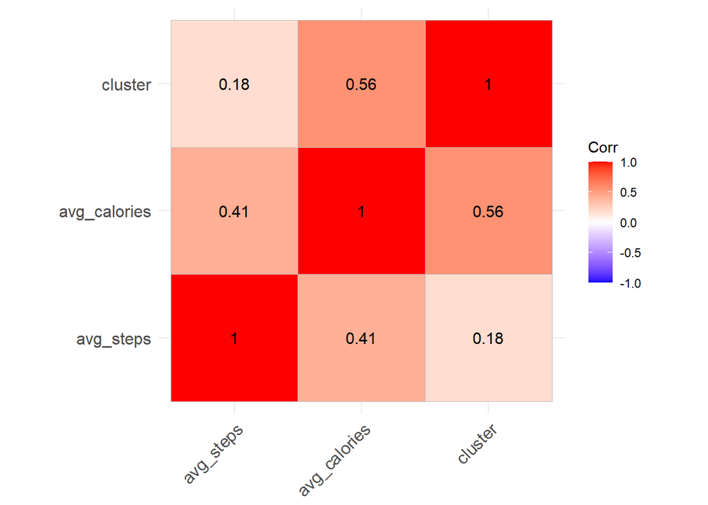

```r
library(ggcorrplot)
cor_matrix <- cor(activity_data[, c("avg_steps", "avg_calories", "cluster")], use="complete.obs")
ggcorrplot(cor_matrix, lab = TRUE)
```

Upon reviewing the correlation results in relation to the earlier clustering findings, it is observed that there is not a perfect alignment between these analyses. Specifically, while the clustering results highlighted significant relationships between activity metrics and clusters, the new correlation analysis indicates variations in these relationships.

These discrepancies could be attributed to several factors, including variations in the clustering algorithm’s sensitivity to different metrics, the inherent variability in individual activity patterns, or the potential redundancy among correlated variables. It is also possible that the clustering process captured broader patterns that are less apparent in the correlation analysis.

Therefore, these discrepancies will not affect the recommendations provided, which are based on the most consistent and actionable findings.

## Suggestions for Bellabeat

1. **Develop an In-App Community Feature**: Create an in-app community feature where users can connect, share their fitness journeys, and motivate each other.
2. **Integrate Nutrition Tracking:** Integrate a nutrition tracking feature into the Bellabeat app to provide a holistic approach to health and wellness.
3. **Implement AI-Powered Personal Training:** Utilize AI to offer personalized training programs and real-time feedback based on users’ fitness data.
4. **Conduct Regular Surveys Periodically:** conduct surveys among current and potential users to gather data on their needs and preferences.
5. **Motivational Features:** Introduce motivational features such as badges, leaderboards, and rewards for achieving certain intensity levels or calorie burn targets. This could encourage users to engage in more intense workouts.

To further enhance the value of Bellabeat’s insights and recommendations, it is recommended that the company expands its data collection to include additional demographic and personal information such as gender, age, and other relevant factors. By implementing these suggestions, Bellabeat can help their users achieve their fitness goals more effectively while also enhancing user engagement and satisfaction with their products.